# Lunar Lander Continuous Control with Proximal Policy Optimization and Generalized Advantage Estimation

## Part 1/2: Implementation & Training

# By: Ken K. Hong

# Abstract:

This project studies reinforcement learning applied to continuous control tasks in the `LunarLanderContinuous-v3` environment. Continuous control differs from discrete action spaces by involving an infinite set of possible actions. Proximal Policy Optimization combined with Generalized Advantage Estimation improves learning stability and performance. More broadly, applying PPO to large language models like ChatGPT on human feedback sharpens their alignment with user intent, resulting in more accurate and reliable outputs. Experimental results highlight the impact of hyperparameters such as `GAE` $\lambda$, `epsilon_decay`, and `hidden_size`, along with the trade-off between model complexity and efficiency. Future work will explore alternative reinforcement learning algorithms, enhance data efficiency, and strengthen generalization. Challenges in real-world deployment include performance variability and environmental complexity. These findings offer insights into the strengths and limitations of reinforcement learning in complex continuous control tasks.

# 1. Introduction

This project explores applying reinforcement learning to complex sequential decision-making problems within continuous control environments. Unlike traditional methods such as tabular SARSA or Q-learning, which operate with a fixed set of discrete actions, continuous control tasks require agents to select from an unlimited range of actions. (Sutton & Barto, 2018) To illustrate the approach, the LunarLanderContinuous-v3 environment from the Gymnasium library is used, where the agent learns to control the lunar lander’s engines to ensure a smooth and accurate landing.

Proximal Policy Optimization (PPO) combined with Generalized Advantage Estimation (GAE) is chosen as the reinforcement learning agent for this task. PPO is selected for its strong performance, training stability, and relative simplicity compared to more complex algorithms like Trust Region Policy Optimization (TRPO), as well as its advantages over other popular methods such as TD3 and DDPG ([Schulman et al., 2017](https://arxiv.org/abs/1707.06347)). PPO has also been used effectively in the alignment and fine-tuning of large language models, including ChatGPT ([Ouyang et al., 2022](https://arxiv.org/abs/2203.02155); [Unsloth, 2025](https://docs.unsloth.ai/basics/reinforcement-learning-guide)). This report outlines the problem setup, rationale for the chosen approach, actor-critic architecture, training process, and agent evaluation, concluding with key insights and suggestions for future work.

# 2. Lunar Lander Continuous Control Environment

The goal is to train a reinforcement learning agent to solve the `LunarLanderContinuous-v3` environment from the Gymnasium library. This environment presents a control challenge based on a physics simulation of a lunar lander. The agent's objective is to learn a policy that guides the lander from a random initial position near the top of the screen to a smooth and accurate landing at the designated target located at coordinates $(0, 0)$. The state space, action space, and reward function are defined as described in the Gymnasium documentation ([Foundation, 2025](https://gymnasium.farama.org/environments/box2d/lunar_lander/)) .

## 2.1 State Space

At each timestep, the agent observes an 8-dimensional state vector that captures the lander’s physical status. The state space $S$ is defined as:

$$ s_t = (x, y, \dot{x}, \dot{y}, \theta, \dot{\theta}, \text{leg}_L, \text{leg}_R) $$

where:

- $x, y$: The horizontal and vertical position coordinates of the lander.
- $\dot{x}, \dot{y}$: The horizontal and vertical velocities.
- $\theta, \dot{\theta}$: The angle and angular velocity of the lander.
- $\text{leg}_L, \text{leg}_R$: Binary indicators showing whether the landing legs are touching the ground.

## 2.2 Action Space

The agent interacts with the environment through a two-dimensional continuous action space $A$, which controls the lander's main and side engines. The action vector is defined as:

$$ a_t = (a_{\text{main}}, a_{\text{side}}) $$

where:

- **Main Engine Throttle** $a_{\text{main}}$: a value in the range $[-1, 1]$ with a non-linear response:
  - If $a_{\text{main}} \in [-1, 0]$, the main engine is off.
  - If $a_{\text{main}} \in (0, 1]$, the throttle is smoothly adjusted from 50% to 100% power.
- **Side Engine Throttle** $a_{\text{side}}$: a value in the range $[-1, 1]$ controlling the left and right orientation thrusters:
  - If $a_{\text{side}} \in [-0.5, 0.5]$, neither side engine fires.
  - If $a_{\text{side}} \in (0.5, 1]$, the right engine fires, scaling smoothly from 50% to 100% power.
  - If $a_{\text{side}} \in [-1, -0.5)$, the left engine fires, scaling smoothly from 50% to 100% power.

## 2.3 Rewards and Termination Condition

The reward structure guides the agent toward a successful landing by combining several components:

- **Terminal Rewards** provide a positive reward of +100 when the lander comes to a complete stop on the landing pad. Conversely, a penalty of -100 is applied if the lander crashes.
- **Shaping Rewards** offer continuous feedback by rewarding the agent for moving closer to the landing pad and penalizing it for moving away.
- **Auxiliary Rewards**: +10 points for each landing leg that touches the ground.
- **Penalties**: $-0.3$ points for each thruster use to encourage fuel efficiency.

The reward structure requires balancing immediate minor penalties, such as fuel consumption, against larger but delayed rewards, including a successful landing. The discount factor $\gamma$ is set to 0.99 for this episodic task, promoting the development of a policy that prioritizes the significant future reward of a safe landing over the small immediate cost of engine use.

An episode terminates when the lander crashes, lands successfully, or moves beyond the visible area. The problem is considered solved when the agent achieves an average score of 200 or higher over 100 consecutive evaluation episodes.

## 2.4 Environmental Factors

The environment simulates physical forces that influence the lander’s behavior:

- **Gravity** pulls the lander downward, typically set between 0 and $-12$.
- **Wind** introduces random variation to the lander’s movement when enabled.
- **Wind Power** controls the strength of linear wind forces.
- **Turbulence Power** determines the intensity of rotational wind effects.

All values in this project use the default settings.

# 3. Clipped Proximal Policy Optimization Implementation with GAE

Clipped Proximal Policy Optimization (PPO) combined with Generalized Advantage Estimation (GAE) provides a robust and effective solution for this task. PPO was chosen over A2C, TD3, and DDPG due to superior training stability, simpler implementation, and success on continuous control benchmarks ([Schulman et al., 2017](https://arxiv.org/abs/1707.06347)). The clipped objective with GAE mitigates large policy updates that destabilize training, resulting in more reliable performance and simplified tuning. Detailed information on PPO implementation is available in ([OpenAI, 2017](https://spinningup.openai.com/en/latest/algorithms/ppo.html)).

## 3.2 The PPO Clipped Surrogate Objective

PPO’s key innovation is the clipped surrogate objective, which uses the probability ratio between new and old policies to limit updates, promoting stable and efficient learning.

$$ r_t(\theta) = \frac{\pi_{\theta}(a_t \mid s_t)}{\pi_{\theta_\text{old}}(a_t \mid s_t)} $$

The objective function is defined as:

$$ L_\text{CLIP}(\theta) = \hat{\mathbb{E}}_t \left[ \min \big( r_t(\theta) \hat{A}_t, \, \text{clip}(r_t(\theta), 1 - \epsilon, 1 + \epsilon) \hat{A}_t \big) \right] $$

In this expression, $\hat{A}_t$ denotes the estimated advantage, and $\epsilon$ specifies the clipping threshold. This approach restricts excessively large updates and avoids the computational complexity associated with methods such as TRPO. Figure 1 presents the pseudocode for PPO implementation.

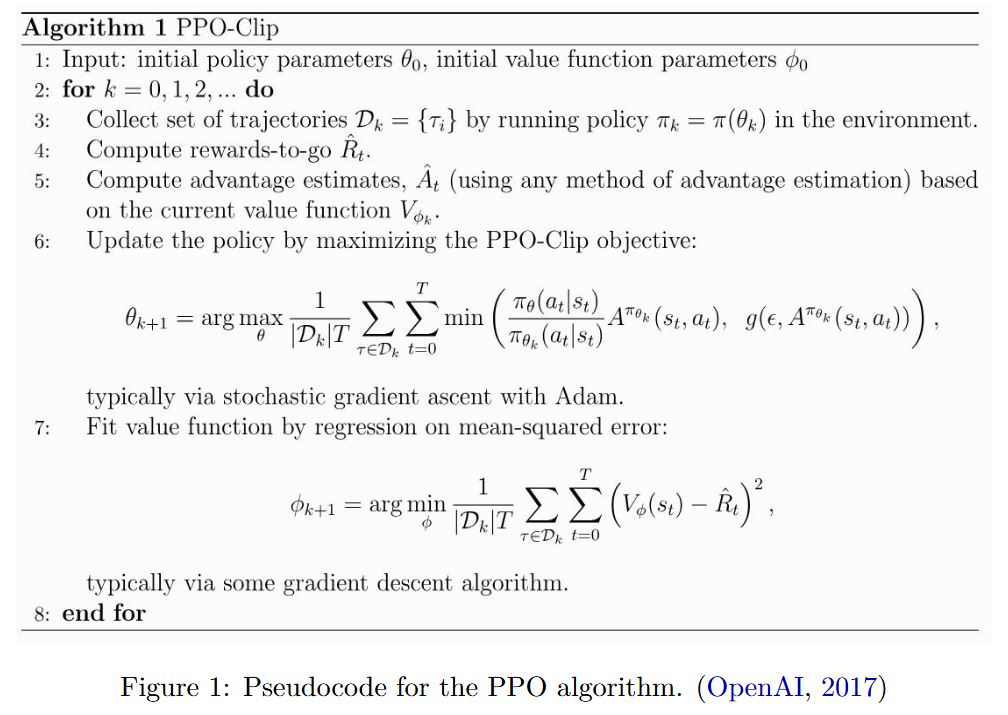

```python
from IPython.display import display, Image
display(Image("/content/Figure1.JPG", width=600, height=400))
```

## 3.3 Generalized Advantage Estimation (GAE)

The effectiveness of policy updates depends on the accuracy of the advantage estimate, defined as $\hat{A}_t = Q(s_t, a_t) - V(s_t)$. GAE enhances this by balancing bias and variance ([Schulman et al., 2015](https://arxiv.org/abs/1506.02438)).

The single-step temporal difference (TD) error,

$$ \delta_t = r_t + \gamma V(s_{t+1}) - V(s_t), $$

has low variance but may introduce bias due to reliance on the critic’s prediction. In contrast, Monte Carlo returns offer an unbiased estimate by using full episode rewards but often suffer from high variance caused by noisy long-term outcomes.

GAE combines these methods through an exponentially weighted sum of TD errors:

$$ \hat{A}^{\text{GAE}}_t(\gamma, \lambda) = (1 - \lambda)\left( \delta_t^V + \lambda(\delta_{t+1}^V) + \lambda^2(\delta_{t+2}^V) + \cdots \right) = \sum_{l=0}^{\infty} (\gamma \lambda)^l \delta_{t+l} $$

The parameter $\lambda$ adjusts the bias-variance trade-off. Values near $0.95$ have proven effective in practice ([Schulman et al., 2015](https://arxiv.org/abs/1506.02438)). Together, GAE provides a smoother and more informative signal for policy updates, while PPO controls the update size, resulting in more stable and efficient learning.

## 3.5 Training Configuration and Gradient Stabilization

Training the PPO agent requires careful optimization and gradient control to maintain stability and efficiency. This section outlines the optimization setup, including the optimizer choice, parameter initialization, and gradient clipping, based on the approach in ([Engstrom et al., 2020](https://arxiv.org/abs/2005.12729)).

**Optimizer**  
Adam optimizer was employed to update both actor and critic networks. Learning rates were determined through empirical tuning and remained constant, resulting in stable and consistent training. Future work may explore cosine decay to gradually reduce the learning rate.

**Gradient Clipping**  
To prevent unstable updates and exploding gradients, gradients were clipped to keep the global norm below 0.5, ensuring stable training and preventing divergence.

**Orthogonal Initialization**  
Weights were initialized orthogonally to preserve gradient scales during backpropagation, promoting better convergence and more stable training.

```python
# To install gymnasium with box2d support, run:
# !apt-get install -y swig
# !pip install "gymnasium[box2d]"
```

```python
import matplotlib.pyplot as plt
import pandas as pd
import numpy as np
from tqdm.notebook import tqdm
import gymnasium as gym
import time
import torch
import torch.nn as nn
import torch.optim as optim
from torch.distributions import Normal
from collections import deque
```

```python
class PolicyNet(nn.Module):
    """ The policy network - the Actor """

    def __init__(self, state_dim, action_dim, hidden_dim=256, dropout_prob=0.2):
        super(PolicyNet, self).__init__()
        # 4-layer MLP with dropout and ReLU non-linearities added
        self.network = nn.Sequential(
            nn.Linear(state_dim, hidden_dim),
            nn.ReLU(),
            nn.Dropout(dropout_prob),
            nn.Linear(hidden_dim, hidden_dim),
            nn.ReLU(),
            nn.Dropout(dropout_prob),
            nn.Linear(hidden_dim, hidden_dim),
            nn.ReLU(),
            nn.Dropout(dropout_prob),
            nn.Linear(hidden_dim, action_dim),

            nn.Tanh() # Tanh return (-1,1 )
            # nn.Softmax()    # Softmax return 0 and 1
        )

        #  Common Practice in PPO and other actor-critic methods for Continuous control
        # action_dim - Dimension of the acttion space
        # nn.Parameter())  registered as a learnable parameter

        self.log_dev = nn.Parameter(torch.zeros(action_dim))

        # Apply orthogonal initialization - https://arxiv.org/abs/2005.12729
        self._init_weights()

    def _init_weights(self):
        for layer in self.network:
            if isinstance(layer, nn.Linear):
                nn.init.orthogonal_(layer.weight, gain=1.0)
                nn.init.constant_(layer.bias, 0)

    def forward(self, state):
        action_val = self.network(state)
        return action_val

class ValueNet(nn.Module):
    """ The value network -  the Critic """
    def __init__(self, state_dim, hidden_dim=256, dropout_prob=0.2):
        super(ValueNet, self).__init__()
        # 4-layer MLP with dropout and ReLU non-linearities added
        self.network = nn.Sequential(
            nn.Linear(state_dim, hidden_dim),
            nn.ReLU(),
            nn.Dropout(dropout_prob),
            nn.Linear(hidden_dim, hidden_dim),
            nn.ReLU(),
            nn.Dropout(dropout_prob),
            nn.Linear(hidden_dim, hidden_dim),
            nn.ReLU(),
            nn.Dropout(dropout_prob),
            nn.Linear(hidden_dim, 1)
        )

        # Apply orthogonal initialization
        self._init_weights()

    def _init_weights(self):
        for layer in self.network:
            if isinstance(layer, nn.Linear):
                nn.init.orthogonal_(layer.weight, gain=1.0)
                nn.init.constant_(layer.bias, 0)

    def forward(self, state):
        state_value = self.network(state)
        return state_value
```

```python
# Memory Buffer:  temporarily stores on-policy experiences to enable efficient batch updates,
# Goal: reducing gradient variance and managing the bias-variance trade-off in advantage estimation.

class RolloutBuffer:
    def __init__(self):
        self.actions = []
        self.states = []
        self.log_probs = []
        self.rewards = []
        self.dones = []
        self.values = []

    def store(self, action, state, log_prob, reward, done, value):
        self.actions.append(action)
        self.states.append(state)
        self.log_probs.append(log_prob)
        self.rewards.append(reward)
        self.dones.append(done)
        self.values.append(value)

    def clear(self):
        del self.actions[:]
        del self.states[:]
        del self.log_probs[:]
        del self.rewards[:]
        del self.dones[:]
        del self.values[:]
```

```python
class PPO_Agent:
    def __init__(self, state_dim, action_dim, lr_actor, lr_critic, gamma, K_epochs, eps_clip, hidden_dim=256, epsilon_decay = 0.995, gae_lambda = 0.95, dropout_prob=0.2):
        self.device = torch.device("cuda" if torch.cuda.is_available() else "cpu")  # Use GPU for the neural network if available

        self.gamma = gamma
        self.eps_clip = eps_clip
        self.K_epochs = K_epochs
        self.gae_lambda = gae_lambda
        self.dropout_prob = dropout_prob

        self.epsilon = 0.6
        self.epsilon_decay = epsilon_decay
        self.min_epsilon = 0.0
        self.action_dim_rand = action_dim

        self.actor = PolicyNet(state_dim, action_dim, hidden_dim, dropout_prob).to(self.device)
        self.optimizer_actor = optim.Adam(self.actor.parameters(), lr=lr_actor)

        self.critic = ValueNet(state_dim, hidden_dim, dropout_prob).to(self.device)
        self.optimizer_critic = optim.Adam(self.critic.parameters(), lr=lr_critic)

        self.mse_loss = nn.MSELoss()  # MSE Loss

    def select_action(self, state):

        if np.random.rand() < self.epsilon:
            # Random action from a uniform distribution
            action = np.random.uniform(-1, 1, self.action_dim_rand)

        with torch.no_grad(): # Forward Pass
            state_tensor = torch.FloatTensor(state).to(self.device)
            action_val = self.actor(state_tensor)
            action_std = torch.exp(self.actor.log_dev)

            dist = Normal(action_val, action_std)
            action = dist.sample()  # Sampel Action from the normal distribution
            log_prob = dist.log_prob(action).sum()
            value = self.critic(state_tensor)

        return action.cpu().numpy(), state, log_prob.item(), value.item()

    def update(self, memory):
        rewards = torch.tensor(memory.rewards, dtype=torch.float32).to(self.device)
        dones = torch.tensor(memory.dones, dtype=torch.float32).to(self.device)

        old_states = torch.squeeze(torch.tensor(np.array(memory.states), dtype=torch.float32)).to(self.device)
        old_actions = torch.squeeze(torch.tensor(np.array(memory.actions), dtype=torch.float32)).to(self.device)
        old_log_probs = torch.squeeze(torch.tensor(memory.log_probs, dtype=torch.float32)).to(self.device)
        old_values = torch.squeeze(torch.tensor(memory.values, dtype=torch.float32)).to(self.device)

        advantages = torch.zeros_like(rewards).to(self.device)
        last_gae_lam = 0
        next_value = 0

        # GAE Paper: https://arxiv.org/pdf/1506.02438

        for t in reversed(range(len(rewards))):  # Reverse Order

            mask = 1.0 - dones[t]

            if t == len(rewards) - 1:
                val_next_state = next_value
            else:
                val_next_state = old_values[t + 1]

            #  TD residual (delta)
            delta = rewards[t] + self.gamma * val_next_state * mask - old_values[t]

            # Update the GAE: recursive form: A^t=δt+γλ⋅maskt⋅A^t+1
            last_gae_lam = delta + self.gamma * self.gae_lambda * mask * last_gae_lam
            advantages[t] = last_gae_lam

        returns = advantages + old_values

        # Normalize advantages
        advantages = (advantages - advantages.mean()) / (advantages.std() + 1e-7)  #epsilon

        # PPO Optimization: https://spinningup.openai.com/en/latest/algorithms/ppo.html
        for _ in range(self.K_epochs):
            action_means = self.actor(old_states)
            action_stds = torch.exp(self.actor.log_dev.expand_as(action_means))
            dist = Normal(action_means, action_stds)

            new_log_probs = dist.log_prob(old_actions).sum(axis=1)
            state_values = self.critic(old_states).squeeze()

            ratios = torch.exp(new_log_probs - old_log_probs)

            surr1 = ratios * advantages
            surr2 = torch.clamp(ratios, 1 - self.eps_clip, 1 + self.eps_clip) * advantages

            #  PPO loss function
            actor_loss = -torch.min(surr1, surr2).mean()

            # Critic loss now
            critic_loss = self.mse_loss(state_values, returns)

            # Total loss:
            #dist_entropy = dist.entropy().mean() #measure of randomness or exploration
            loss = actor_loss + 0.5 * critic_loss  #- 0.01 * dist_entropy

            # Take gradient step for actor
            self.optimizer_actor.zero_grad()
            actor_loss.backward(retain_graph=True)

            # Take gradient step for critic
            self.optimizer_critic.zero_grad()
            critic_loss.backward()

            # Clip gradients to prevent exploding gradients - https://arxiv.org/abs/2005.12729
            torch.nn.utils.clip_grad_norm_(self.actor.parameters(), max_norm=0.5)
            torch.nn.utils.clip_grad_norm_(self.critic.parameters(), max_norm=0.5)

            self.optimizer_actor.step()
            self.optimizer_critic.step()

        self.epsilon = max(self.min_epsilon, self.epsilon * self.epsilon_decay)

    def save(self, filepath):
        torch.save({ 'actor_state_dict': self.actor.state_dict(),  'critic_state_dict': self.critic.state_dict(), }, filepath)
        print(f"Saved model to {filepath}")
```

```python
def train_agent(env, hyperparams, filepath = 'final_model'):
    """ training loop for one set of hyperparameters

    --- Sample Outputs ---
                env.observation_space  = Box([ -2.5        -2.5       -10.        -10.         -6.2831855 -10.
                  -0.         -0.       ], [ 2.5        2.5       10.        10.         6.2831855 10.
                  1.         1.       ], (8,), float32)

                env.action_space  = Box(-1.0, 1.0, (2,), float32)
    """

    state_dim = env.observation_space.shape[0]
    action_dim = env.action_space.shape[0]

    agent_params = {
        'lr_actor': hyperparams['lr_actor'],
        'lr_critic': hyperparams['lr_critic'],
        'gamma': hyperparams['gamma'],
        'K_epochs': hyperparams['K_epochs'],
        'eps_clip': hyperparams['eps_clip'],
        'hidden_dim': hyperparams.get('hidden_dim', 256),  #   Default 256,
        'epsilon_decay': hyperparams.get('epsilon_decay', 0.995),  #   Default 0.995
        'gae_lambda': hyperparams.get('gae_lambda', 0.95),  #   Default 0.95
        'dropout_prob': hyperparams.get('dropout_prob', 0.2)  #   Default 0.2
    }
    agent = PPO_Agent(state_dim, action_dim, **agent_params)
    memory = RolloutBuffer()
    print(f"\n{filepath} \ntraining with params:\n{hyperparams}")

    rewards_log = []
    std_log = {}
    recent_scores = deque(maxlen=100)  # Automatic sliding window that keeps the most recent 100 items.
    timestep = 0
    start_time = time.time()

    for episode in tqdm(range(1, int(hyperparams['num_episodes']) + 1), desc="Training Episodes"):  # Progress Bar
        state, _ = env.reset()
        episode_reward = 0
        for t in range(int(hyperparams['max_timesteps'])):  # for number of timesteps
            timestep += 1
            action, state_val, log_prob, value = agent.select_action(state)
            next_state, reward, terminated, truncated, _ = env.step(action)
            done = terminated or truncated

            memory.store(action, state_val, log_prob, reward, done, value)
            state = next_state
            episode_reward += reward

            if timestep % hyperparams['update_timestep'] == 0:
                agent.update(memory)
                memory.clear()

            if done: #  terminated or truncated
                break


        rewards_log.append(episode_reward)
        recent_scores.append(episode_reward)

        total_time = time.time() - start_time
        minutes, seconds = divmod(total_time, 60)
        avg_last_100 = np.mean(recent_scores)
        std_last_100 = np.std(recent_scores)
        std_log[episode] = std_last_100

        # Print average every 100 episodes for debugging
        if episode % 100 == 0:
            print(f"Episode {episode}: Average reward over last {len(recent_scores)} episodes = {np.mean(recent_scores):.2f} | Standard deviation: {std_last_100:.2f}")

        # The problem is considered solved when achieving an average score of 200 or higher over 100 consecutive episodes.
        if len(recent_scores) == 100 and np.mean(recent_scores) >= 200:
            print("\n"+"-" * 150)
            print(f"Environment solved in {episode} episodes | Average reward over last 100 episodes: {avg_last_100:.2f}")
            print(f"Total training time: {int(minutes)} minutes {int(seconds)} seconds")

            agent.save(filepath + ".pth")
            break

    return rewards_log, agent, std_log
```

```python
def plot_results(key, results_dict, params):
    """ Plots the results of hyperparameter experiments.

        Sample Output:
          results_dict:
          {'baseline': {'rewards': ([np.float64(-88.42352214639779),np.float64(-379.1623722148125), ...
                                'params': {'lr_actor': 0.0003,
                                'lr_critic': 0.0005,
                                'gamma': 0.99,
                                'K_epochs': 15,
                                'eps_clip': 0.2,
                                'hidden_dim': 256,
                                'gae_lambda': 0.95,
                                'dropout_prob': 0.1,
                                'num_episodes': 2500,
                                'max_timesteps': 1000,
                                'update_timestep': 500}}}
    """

    rewards_list = results_dict['rewards'][0]

    moving_avg = []
    if len(rewards_list) >= 100:
        moving_avg = [np.mean(rewards_list[j:j+100]) for j in range(len(rewards_list) - 99)]

    plt.figure(figsize=(10, 6))
    plt.plot(rewards_list, alpha=0.5, label='Episode Reward')

    if moving_avg is not None:
        plt.plot(range(99, len(rewards_list)), moving_avg, color='r', linestyle='-', lw=2, label='100-Episode Moving Average')


    if len(rewards_list) > 2000:
        x_pos = 1800
    else:
        x_pos = len(rewards_list) + 30

    y_pos = moving_avg[-1] + 30

    status_text = (
        f'Training Complete\n({len(rewards_list)} episodes)'
        if len(rewards_list) < 2500
        else 'Training Incomplete\n(max episodes reached)'
    )

    y_pos = moving_avg[-1] + 30
    plt.annotate(status_text,
                 xy=(x_pos, y_pos),
                 xytext=(x_pos, y_pos),
                 fontsize=16,
                 color='red')

    plt.axhline(y=200, color='k', linestyle='--', label='Reward Threshold - 200')

    param_str = str(tuple(current_params.values()))
    plt.title(f"Training: {key} | Random Seed: 1\n {param_str}", fontsize=16, fontweight='bold', pad=15)

    param_text = '\n'.join([f"{k}: {v}" for k, v in params.items()])
    plt.xlabel("Episode", fontsize=16, fontweight='bold')
    plt.ylabel("Reward", fontsize=16, fontweight='bold')
    plt.xticks(rotation=0, fontsize=14)
    plt.yticks(rotation=0, fontsize=14)

    #plt.xlim(right=2500)
    plt.xlim(0, 2500)
    plt.ylim(-400, 300)
    plt.legend(loc='lower right', fontsize=16, title_fontsize=12)
    plt.tight_layout()

    plt.grid(True)
    plt.tight_layout()

    plt.savefig(f"{key}_training_plot.png")
    print(f"Saved plot to {key}_training_plot.png")
    print("\n")
    plt.show()

#plot_results(experiment_results, current_params)
```

# 4. Experimental Setup

Baseline PPO model configured using default parameters drawn from existing literature and practical experience, establishing a consistent benchmark. Trial variants altered one or more parameters to evaluate hyperparameter effects, isolating individual impacts and examining interactions.

## 4.1 Hyperparameter Overview

Performance of the PPO model depends on several hyperparameters affecting training stability, exploration, and model capacity. A baseline configuration used standard values derived from practical experience. Each trial variant modified a single hyperparameter to assess the impact. Comparison metrics included learning speed, reward outcomes, and variability. Primary hyperparameters included GAE lambda balancing bias and variance, epsilon decay controlling exploration, clipping threshold enforcing update stability, and hidden layer size determining model complexity.

## 4.2 Tuning Process and Metrics

Experimental runs compared each variant to the baseline while tracking key metrics: episode count, average reward over the last 100 episodes, standard deviation over the last 100 episodes, and completion time in minutes and seconds to evaluate configuration impact. The table below details baseline values and trial variants with one hyperparameter changed in each trial.

### Table 1: Summary of hyperparameters used in the PPO training process

| Hyperparameter | Symbol | Description | Baseline | Trials |
| --- | --- | --- | --- | --- |
| lr_actor | $\alpha_a$ | Learning rate for the actor network | 0.0002 | 0.0002 |
| lr_critic | $\alpha_c$ | Learning rate for the critic network | 0.001 | 0.001 |
| gamma | $\gamma$ | Discount factor | 0.99 | 0.99 |
| K_epochs | $K$ | Number of epochs per update | 20 | 20 |
| dropout_prob | $p_d$ | Dropout probability | 0.1 | 0.1 |
| num_episodes | $N_e$ | Total number of training episodes | 2500 | 2500 |
| max_timesteps | $T_{max}$ | Maximum timesteps per episode | 2000 | 2000 |
| update_timestep | $T_u$ | Timesteps before each policy update | 512 | 512 |
| gae_lambda | $\lambda$ | GAE lambda parameter | 0.95 | **0.8 (trial 1)** |
| epsilon_decay | $\delta$ | Decay rate for exploration | 0.995 | **0.6 (trial 2)** |
| eps_clip | $\epsilon$ | Clipping parameter for update size | 0.2 | **0.4 (trial 3)** |
| hidden_dim | $h$ | Number of units in hidden layers | 256 | **128 (trial 4)** |

```python
# Use continuous action space environment
env = gym.make("LunarLanderContinuous-v3")  # Use "human" for rendering view window (pop-up)

base_params = {
    'lr_actor': 2e-4,          # Actor learning rate
    'lr_critic': 1e-3,         # Critic learning rate
    'gamma': 0.99,             # Discount factor (near 1 for episodic tasks)
    'K_epochs': 20,            # Gradient descent passes per batch
    'eps_clip': 0.2,           # PPO clipping parameter
    'hidden_dim': 256,         # Hidden layer size
    'epsilon_decay': 0.995,    # Exploration decay rate
    'gae_lambda': 0.95,        # GAE lambda parameter
    'dropout_prob': 0.1,       # Dropout probability
    'num_episodes': 2500,      # Total training episodes
    'max_timesteps': 2000,     # Max steps per episode
    'update_timestep': 512     # Policy update frequency (steps)
    # Smaller update_timestep → frequent updates, high variance, instability
}

# Different hyperparameter sets for fine-tuning
hyperparam_sets = {
    "baseline": {},  # Use default base_params

    "trial1_gae_lambda_0.8": {  # Lower GAE lambda for lower variance, higher bias
        'gae_lambda': 0.8},

    "trial2_epsilon_decay_0.6": {  # Faster exploration decay
        'epsilon_decay': 0.6},

    "trial3_ppo_clip_0.4": {  # Less strict PPO clipping
        'eps_clip': 0.4 },

    "trial4_network_hidden_128": {  # Smaller hidden layer size
        'hidden_dim': 128 },

    "Final_Model": {  # Final model parameters
        'gae_lambda': 0.94,
        'epsilon_decay': 0.8,
        'eps_clip': 0.25,
        'hidden_dim': 256 },
}
```

```python
def set_seed(seed, env=None):
    np.random.seed(seed)
    torch.manual_seed(seed)
    if torch.cuda.is_available():
        torch.cuda.manual_seed_all(seed)

    if env is not None:
        env.reset(seed=seed)
        env.action_space.seed(seed)
        env.observation_space.seed(seed)

seed = 1
set_seed(seed, env)
```

```
baseline
training with params:
{'lr_actor': 0.0002, 'lr_critic': 0.001, 'gamma': 0.99, 'K_epochs': 20, 'eps_clip': 0.2, 'hidden_dim': 256, 'epsilon_decay': 0.995, 'gae_lambda': 0.95, 'dropout_prob': 0.1, 'num_episodes': 2500, 'max_timesteps': 2000, 'update_timestep': 512}
```

```
Episode 100: Average reward over last 100 episodes = -143.03 | Standard deviation: 117.53
Episode 200: Average reward over last 100 episodes = -22.68 | Standard deviation: 109.58
Episode 300: Average reward over last 100 episodes = 21.89 | Standard deviation: 96.59
Episode 400: Average reward over last 100 episodes = 80.09 | Standard deviation: 70.31
Episode 500: Average reward over last 100 episodes = 55.48 | Standard deviation: 95.19
Episode 600: Average reward over last 100 episodes = 50.51 | Standard deviation: 104.31
Episode 700: Average reward over last 100 episodes = 47.12 | Standard deviation: 115.79
Episode 800: Average reward over last 100 episodes = 37.12 | Standard deviation: 76.44
Episode 900: Average reward over last 100 episodes = 110.77 | Standard deviation: 136.05
Episode 1000: Average reward over last 100 episodes = 114.61 | Standard deviation: 150.91
Episode 1100: Average reward over last 100 episodes = 184.90 | Standard deviation: 121.12

---------------------------------------------------------------------------------------------------------------------
Environment solved in 1107 episodes | Average reward over last 100 episodes: 200.69
Total training time: 6 minutes 17 seconds
Saved model to baseline.pth
Saved reward to baseline_reward.csv
Saved std_log to baseline_std.csv
Saved plot to baseline_training_plot.png
```

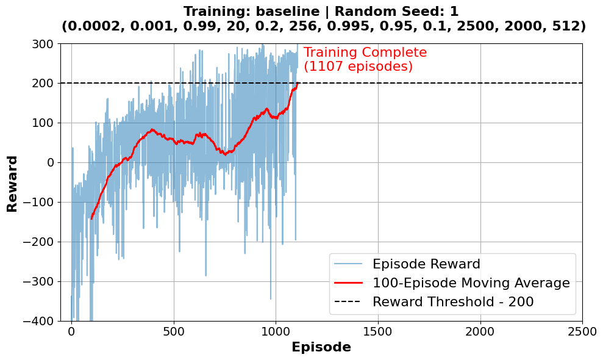

```
---------------------------------------------------------------------------------------------------------------------



trial1_gae_lambda_0.8
training with params:
{'lr_actor': 0.0002, 'lr_critic': 0.001, 'gamma': 0.99, 'K_epochs': 20, 'eps_clip': 0.2, 'hidden_dim': 256, 'epsilon_decay': 0.995, 'gae_lambda': 0.8, 'dropout_prob': 0.1, 'num_episodes': 2500, 'max_timesteps': 2000, 'update_timestep': 512}
```

```
Episode 100: Average reward over last 100 episodes = -114.32 | Standard deviation: 108.76
Episode 200: Average reward over last 100 episodes = -91.58 | Standard deviation: 66.46
Episode 300: Average reward over last 100 episodes = -82.96 | Standard deviation: 56.25
Episode 400: Average reward over last 100 episodes = -76.64 | Standard deviation: 59.08
Episode 500: Average reward over last 100 episodes = -40.74 | Standard deviation: 68.26
Episode 600: Average reward over last 100 episodes = -59.97 | Standard deviation: 72.44
Episode 700: Average reward over last 100 episodes = -76.71 | Standard deviation: 70.62
Episode 800: Average reward over last 100 episodes = -28.14 | Standard deviation: 88.56
Episode 900: Average reward over last 100 episodes = -30.00 | Standard deviation: 89.10
Episode 1000: Average reward over last 100 episodes = -2.06 | Standard deviation: 106.62
Episode 1100: Average reward over last 100 episodes = -22.99 | Standard deviation: 103.25
Episode 1200: Average reward over last 100 episodes = 87.74 | Standard deviation: 121.38
Episode 1300: Average reward over last 100 episodes = 93.98 | Standard deviation: 140.18
Episode 1400: Average reward over last 100 episodes = 35.03 | Standard deviation: 120.19
Episode 1500: Average reward over last 100 episodes = 125.46 | Standard deviation: 131.02
Episode 1600: Average reward over last 100 episodes = 166.33 | Standard deviation: 110.49
Episode 1700: Average reward over last 100 episodes = 98.43 | Standard deviation: 110.79
Episode 1800: Average reward over last 100 episodes = 145.69 | Standard deviation: 129.70
Episode 1900: Average reward over last 100 episodes = 160.15 | Standard deviation: 107.10
Episode 2000: Average reward over last 100 episodes = 114.84 | Standard deviation: 148.41
Episode 2100: Average reward over last 100 episodes = 109.94 | Standard deviation: 145.71

---------------------------------------------------------------------------------------------------------------------
Environment solved in 2189 episodes | Average reward over last 100 episodes: 201.33
Total training time: 13 minutes 5 seconds
Saved model to trial1_gae_lambda_0.8.pth
Saved reward to trial1_gae_lambda_0.8_reward.csv
Saved std_log to trial1_gae_lambda_0.8_std.csv
Saved plot to trial1_gae_lambda_0.8_training_plot.png
```

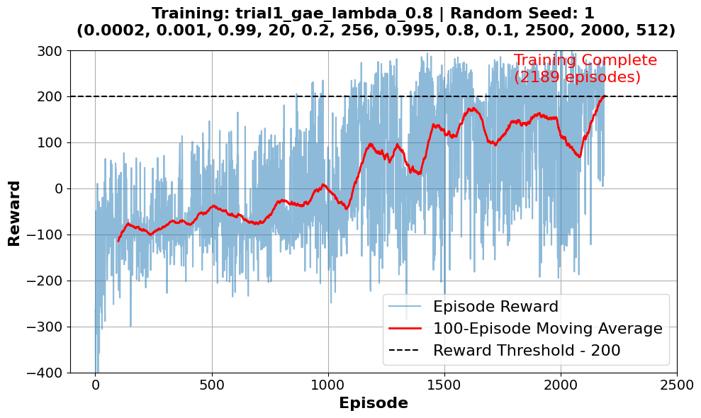

```
---------------------------------------------------------------------------------------------------------------------



trial2_epsilon_decay_0.6
training with params:
{'lr_actor': 0.0002, 'lr_critic': 0.001, 'gamma': 0.99, 'K_epochs': 20, 'eps_clip': 0.2, 'hidden_dim': 256, 'epsilon_decay': 0.6, 'gae_lambda': 0.95, 'dropout_prob': 0.1, 'num_episodes': 2500, 'max_timesteps': 2000, 'update_timestep': 512}
```

```
Episode 100: Average reward over last 100 episodes = -129.05 | Standard deviation: 120.88
Episode 200: Average reward over last 100 episodes = -39.63 | Standard deviation: 89.22
Episode 300: Average reward over last 100 episodes = -28.47 | Standard deviation: 124.25
Episode 400: Average reward over last 100 episodes = 21.33 | Standard deviation: 92.59
Episode 500: Average reward over last 100 episodes = 44.41 | Standard deviation: 100.60
Episode 600: Average reward over last 100 episodes = 37.23 | Standard deviation: 124.90
Episode 700: Average reward over last 100 episodes = 71.86 | Standard deviation: 103.32
Episode 800: Average reward over last 100 episodes = 99.40 | Standard deviation: 103.68
Episode 900: Average reward over last 100 episodes = 119.35 | Standard deviation: 138.93
Episode 1000: Average reward over last 100 episodes = 199.97 | Standard deviation: 100.66

---------------------------------------------------------------------------------------------------------------------
Environment solved in 1002 episodes | Average reward over last 100 episodes: 201.58
Total training time: 7 minutes 29 seconds
Saved model to trial2_epsilon_decay_0.6.pth
Saved reward to trial2_epsilon_decay_0.6_reward.csv
Saved std_log to trial2_epsilon_decay_0.6_std.csv
Saved plot to trial2_epsilon_decay_0.6_training_plot.png
```

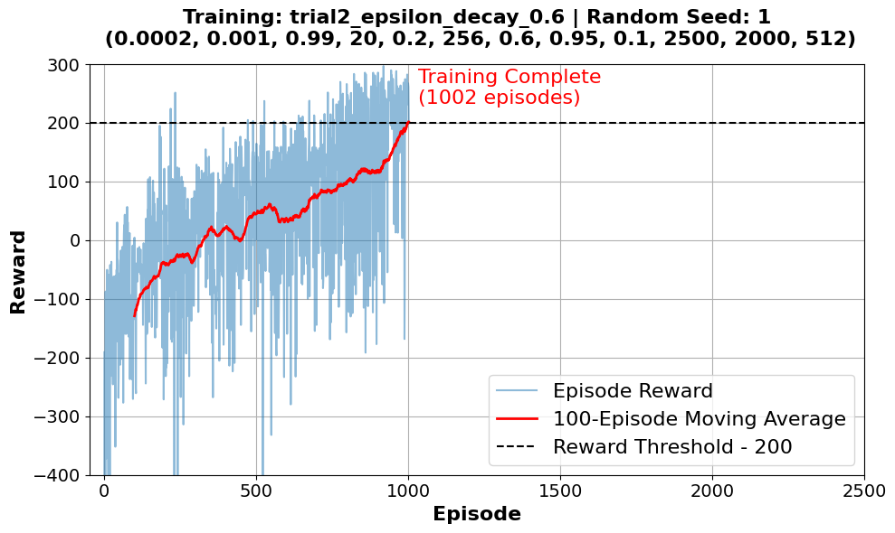

```
---------------------------------------------------------------------------------------------------------------------



trial3_ppo_clip_0.4
training with params:
{'lr_actor': 0.0002, 'lr_critic': 0.001, 'gamma': 0.99, 'K_epochs': 20, 'eps_clip': 0.4, 'hidden_dim': 256, 'epsilon_decay': 0.995, 'gae_lambda': 0.95, 'dropout_prob': 0.1, 'num_episodes': 2500, 'max_timesteps': 2000, 'update_timestep': 512}
```

```
Episode 100: Average reward over last 100 episodes = -123.38 | Standard deviation: 122.48
Episode 200: Average reward over last 100 episodes = 23.60 | Standard deviation: 82.43
Episode 300: Average reward over last 100 episodes = 39.80 | Standard deviation: 77.71
Episode 400: Average reward over last 100 episodes = -7.38 | Standard deviation: 125.28
Episode 500: Average reward over last 100 episodes = 72.10 | Standard deviation: 102.77
Episode 600: Average reward over last 100 episodes = 98.34 | Standard deviation: 129.91
Episode 700: Average reward over last 100 episodes = 162.06 | Standard deviation: 110.20
Episode 800: Average reward over last 100 episodes = 183.05 | Standard deviation: 101.91
Episode 900: Average reward over last 100 episodes = 153.25 | Standard deviation: 122.43
Episode 1000: Average reward over last 100 episodes = 179.04 | Standard deviation: 104.53
Episode 1100: Average reward over last 100 episodes = 188.16 | Standard deviation: 111.67

---------------------------------------------------------------------------------------------------------------------
Environment solved in 1125 episodes | Average reward over last 100 episodes: 200.27
Total training time: 7 minutes 42 seconds
Saved model to trial3_ppo_clip_0.4.pth
Saved reward to trial3_ppo_clip_0.4_reward.csv
Saved std_log to trial3_ppo_clip_0.4_std.csv
Saved plot to trial3_ppo_clip_0.4_training_plot.png
```

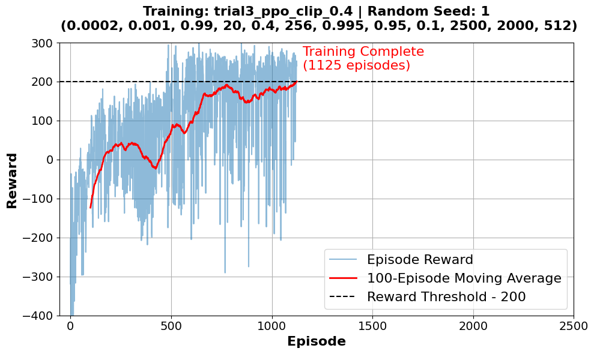

```
---------------------------------------------------------------------------------------------------------------------



trial4_network_hidden_128
training with params:
{'lr_actor': 0.0002, 'lr_critic': 0.001, 'gamma': 0.99, 'K_epochs': 20, 'eps_clip': 0.2, 'hidden_dim': 128, 'epsilon_decay': 0.995, 'gae_lambda': 0.95, 'dropout_prob': 0.1, 'num_episodes': 2500, 'max_timesteps': 2000, 'update_timestep': 512}
```

```
Episode 100: Average reward over last 100 episodes = -145.64 | Standard deviation: 113.73
Episode 200: Average reward over last 100 episodes = -47.46 | Standard deviation: 89.37
Episode 300: Average reward over last 100 episodes = -22.67 | Standard deviation: 90.47
Episode 400: Average reward over last 100 episodes = 20.96 | Standard deviation: 81.90
Episode 500: Average reward over last 100 episodes = 58.83 | Standard deviation: 88.12
Episode 600: Average reward over last 100 episodes = 39.97 | Standard deviation: 104.20
Episode 700: Average reward over last 100 episodes = 60.88 | Standard deviation: 98.82
Episode 800: Average reward over last 100 episodes = 123.66 | Standard deviation: 97.20
Episode 900: Average reward over last 100 episodes = 113.92 | Standard deviation: 141.87
Episode 1000: Average reward over last 100 episodes = 82.77 | Standard deviation: 130.58
Episode 1100: Average reward over last 100 episodes = 119.46 | Standard deviation: 136.42
Episode 1200: Average reward over last 100 episodes = 140.02 | Standard deviation: 127.04
Episode 1300: Average reward over last 100 episodes = 148.95 | Standard deviation: 120.28
Episode 1400: Average reward over last 100 episodes = 164.45 | Standard deviation: 126.01
Episode 1500: Average reward over last 100 episodes = 98.84 | Standard deviation: 141.74
Episode 1600: Average reward over last 100 episodes = 106.49 | Standard deviation: 145.03
Episode 1700: Average reward over last 100 episodes = 138.41 | Standard deviation: 130.69
Episode 1800: Average reward over last 100 episodes = 153.49 | Standard deviation: 125.07
Episode 1900: Average reward over last 100 episodes = 181.95 | Standard deviation: 122.06

---------------------------------------------------------------------------------------------------------------------
Environment solved in 1937 episodes | Average reward over last 100 episodes: 201.33
Total training time: 8 minutes 1 seconds
Saved model to trial4_network_hidden_128.pth
Saved reward to trial4_network_hidden_128_reward.csv
Saved std_log to trial4_network_hidden_128_std.csv
Saved plot to trial4_network_hidden_128_training_plot.png
```

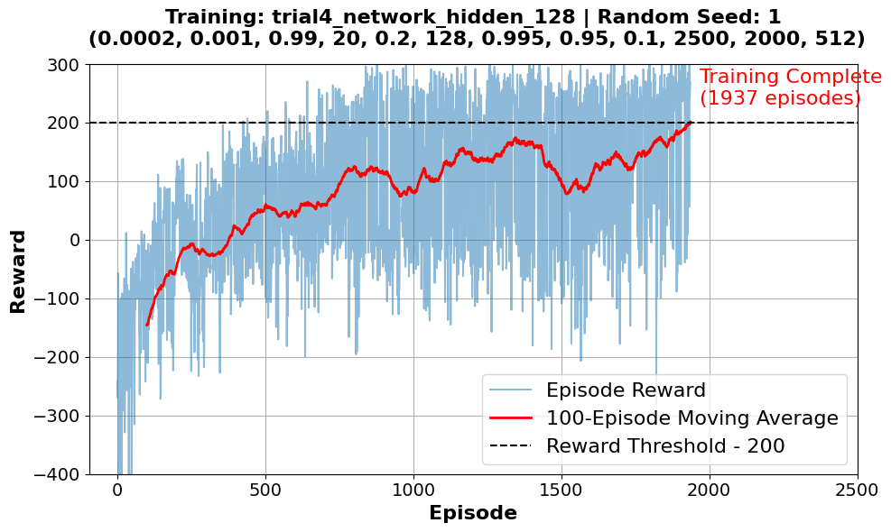

```python
experiment_results = {}
for name, params in hyperparam_sets.items():
    current_params = base_params.copy()
    current_params.update(params)

    # Use Colab v6e-1 TPU  -  Usage rate: approximately 4.15 per hour
    rewards_history, agent, std_log = train_agent(env, current_params, name)
    rewards = [rewards_history, agent]
    experiment_results[name] = {'rewards': rewards, 'params': current_params}

    df_reward = pd.DataFrame(rewards[0], columns=['reward'])
    df_reward.to_csv(f"{name}_reward.csv", index=True)
    print(f"Saved reward to {name}_reward.csv")

    df_std = pd.DataFrame(std_log, index=[0]).T
    df_std.columns = ['std']
    df_std.to_csv(f"{name}_std.csv", index=True)
    print(f"Saved std_log to {name}_std.csv")

    plot_results(name, experiment_results[name], current_params)
    print("-"*150 + "\n\n")
```